# Assignment #5

Tshering Wangchuk

11/8/2021

```r
# SEE modeldata package for new datasets
library(tidyverse)         # for graphing and data cleaning
library(tidymodels)        # for modeling
library(ranger)            # for random forest - will need for shiny app
library(lubridate)         # for date manipulation
library(themis)            # for up and downsampling
library(DALEX)             # for model interpretation
library(DALEXtra)          # for extension of DALEX
theme_set(theme_minimal()) # Lisa's favorite theme
```

```r
data("lending_club")
# Data dictionary (as close as I could find): https://www.kaggle.com/wordsforthewise/lending-club/discussion/170691
```

When you finish the assignment, remove the `#` from the options chunk at the top, so that messages and warnings aren’t printed. If you are getting errors in your code, add `error = TRUE` so that the file knits. I would recommend not removing the `#` until you are completely finished.

## Put it on GitHub!

**Link to Github**: [Tshering’s Assignment 5 Repository](https://github.com/twangchu99/Assignment_5)

## Interpretable ML methods

We will once again use the lending club data that we used in the 3rd assignment. We will focus on the random forest model, which I recreate below. (Note we use this model even though the true negative rate of the training set is quite bad.)

```r
set.seed(494) # for reproducibility

#split data
lending_split <- initial_split(lending_club,
                               prop = .75,
                               strata = Class)

lending_training <- training(lending_split)
lending_test <- testing(lending_split)


#create recipe - including up and downsampling for model fitting
set.seed(456)
rf_recipe <-
  recipe(Class ~ .,
         data = lending_training) %>%
  step_upsample(Class, over_ratio = .5) %>%
  step_downsample(Class, under_ratio = 1) %>%
  step_mutate_at(all_numeric(),
                 fn = ~as.numeric(.))

# create model
rf_model <-
  rand_forest(mtry = tune(),
              min_n = tune(),
              trees = 100) %>%
  set_mode("classification") %>%
  set_engine("ranger")

# create workflow
rf_workflow <-
  workflow() %>%
  add_recipe(rf_recipe) %>%
  add_model(rf_model)

  grid_regular(finalize(mtry(),
                        lending_training %>%
                          select(-Class)),
               min_n(),
               levels = 3)
```

| mtry | min_n |
| --- | --- |
| 1 | 2 |
| 11 | 2 |
| 22 | 2 |
| 1 | 21 |
| 11 | 21 |
| 22 | 21 |
| 1 | 40 |
| 11 | 40 |
| 22 | 40 |

```r
# create penalty grid
  rf_penalty_grid <-
grid_regular(finalize(mtry(),
                        lending_training %>%
                          select(-Class)),
               min_n(),
               levels = 3)


# create cv samples
set.seed(494) #for reproducible 5-fold
lending_cv <- vfold_cv(lending_training,
                       v = 5)

# tune model
rf_tune <-
  rf_workflow %>%
  tune_grid(
    resamples = lending_cv,
    grid = rf_penalty_grid
  )

# find model with best accuracy
best_accuracy <-
  rf_tune %>%
  select_best(metric = "accuracy")

# finalize model
rf_final <- rf_workflow %>%
  finalize_workflow(best_accuracy) %>%
  fit(data = lending_training)
```

1. Use functions from the `DALEX` and `DALEXtra` libraries to create a histogram and boxplot of the residuals from the training data. How do they look? Any interesting behavior?

```r
rf_dalex <-
  explain_tidymodels(
    model = rf_final,
    data = lending_training %>% select(-Class),
    y = lending_training %>%
      mutate(Class_num = as.integer(Class =="good")) %>%
      pull(Class_num),
    label = "rf"
  )
```

```
## Preparation of a new explainer is initiated
##   -> model label       :  rf
##   -> data              :  7392  rows  22  cols
##   -> data              :  tibble converted into a data.frame
##   -> target variable   :  7392  values
##   -> predict function  :  yhat.workflow  will be used (  default  )
##   -> predicted values  :  No value for predict function target column. (  default  )
##   -> model_info        :  package tidymodels , ver. 0.1.4 , task classification (  default  )
##   -> predicted values  :  numerical, min =  0 , mean =  0.8477854 , max =  1
##   -> residual function :  difference between y and yhat (  default  )
##   -> residuals         :  numerical, min =  -0.095 , mean =  0.1004018 , max =  0.72
##   A new explainer has been created!
```

```r
rf_mod_perform <- model_performance(rf_dalex)
```

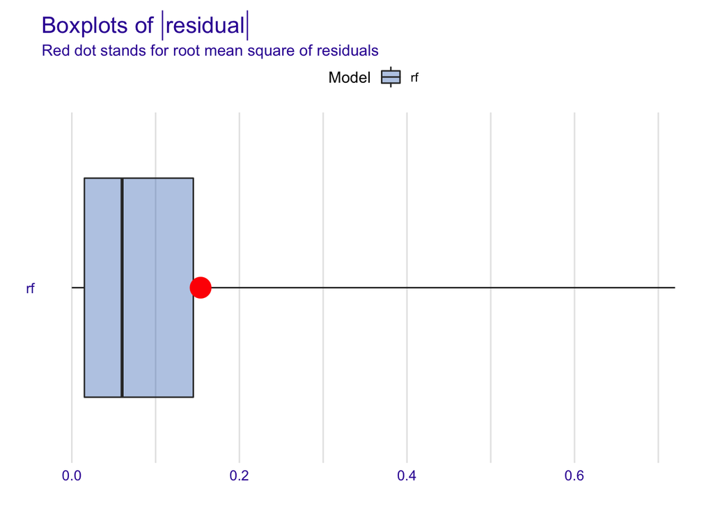

```r
box_plot <-
  plot(rf_mod_perform,
       geom = "boxplot")
hist_plot <-
  plot(rf_mod_perform,
       geom = "histogram")
box_plot
```

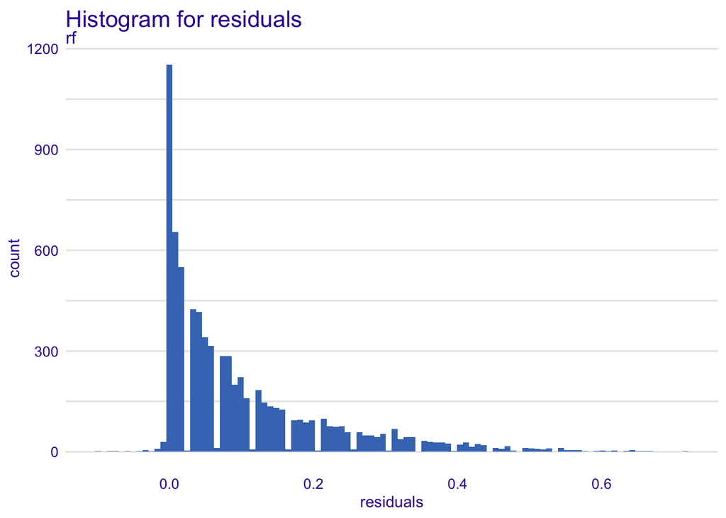

```r
hist_plot
```

3. Write a function called `cp_profile` to make a CP profile. The function will take an explainer, a new observation, and a variable name as its arguments and create a CP profile for a quantitative predictor variable. You will need to use the `predict_profile()` function inside the function you create - put the variable name there so the plotting part is easier. You’ll also want to use `.data[[]]` rather than `aes()` and quote the variables. Use the `cp_profile()` function to create one CP profile of your choosing. Be sure to choose a variable that is numeric, not integer. There seem to be issues with those that I’m looking into.

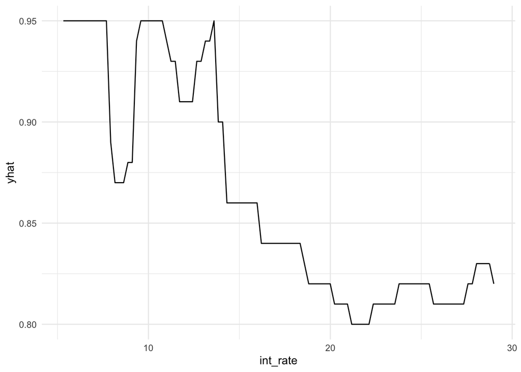

```r
cp_profile <- function(explainer, new_observation, variable){
  pred_prof <- predict_profile(
  explainer = explainer,
  new_observation = new_observation,
  variables = variable)

  pred_prof %>%
  rename(yhat = `_yhat_` ) %>%
  ggplot(aes_string(x = variable,
                    y = "yhat")) +
  geom_line()
}

cp_profile(
  explainer = rf_dalex,
  new_observation = lending_test %>% slice(5),
  variable = "int_rate"
  )
```

For an extra challenge, write a function that will work for either a quantitative or categorical variable.

If you need help with function writing check out the [Functions](https://r4ds.had.co.nz/functions.html) chapter of R4DS by Wickham and Grolemund.

4. Use `DALEX` functions to create partial dependence plots (with the CP profiles in gray) for the 3-4 most important variables. If the important variables are categorical, you can instead make a CP profile for 3 observations in the dataset and discuss how you could go about constructing a partial dependence plot for a categorical variable (you don’t have to code it, but you can if you want an extra challenge). If it ever gives you an error that says, “Error: Can’t convert from `VARIABLE` to `VARIABLE` due to loss of precision”, then remove that variable from the list. I seem to have figured out why it’s doing that, but I don’t know how to fix it yet.

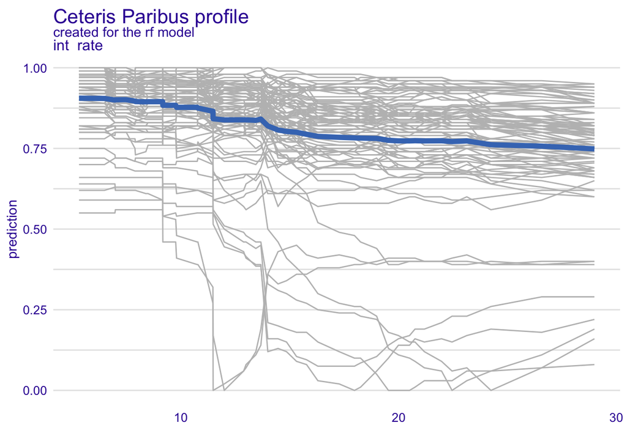

```r
rf_pdp <- model_profile(explainer = rf_dalex,
                        variables = c("int_rate",
                                      "annual_inc",
                                      "revol_util"))

int_rate <-
  plot(rf_pdp,
     variables = "int_rate",
     geom = "profiles")

annual_inc <-
  plot(rf_pdp,
     variables = "annual_inc",
     geom = "profiles")

revol_util<-
  plot(rf_pdp,
     variables = "revol_util",
     geom = "profiles")

int_rate
```

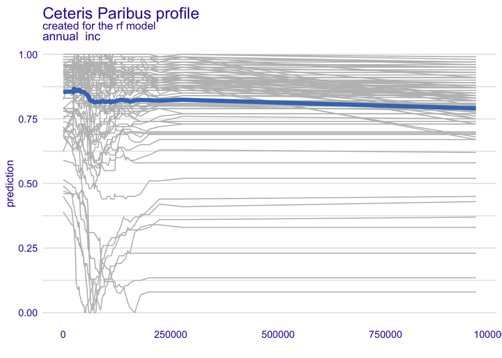

```r
annual_inc
```

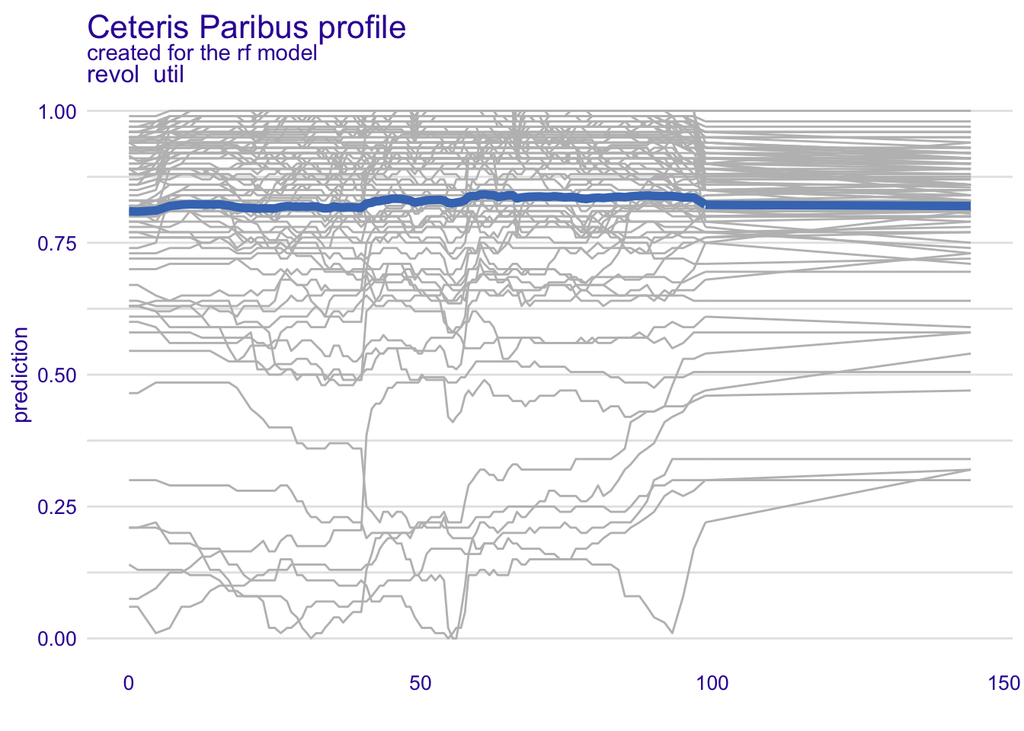

```r
revol_util
```

```r
lending_test
```

| funded_amnt | term | int_rate | sub_grade | addr_state | verification_status | annual_inc | emp_length | delinq_2yrs | inq_last_6mths | revol_util | acc_now_delinq | open_il_6m | open_il_12m | open_il_24m | total_bal_il | all_util | inq_fi | inq_last_12m | delinq_amnt | num_il_tl | total_il_high_credit_limit | Class |
| --- | --- | --- | --- | --- | --- | --- | --- | --- | --- | --- | --- | --- | --- | --- | --- | --- | --- | --- | --- | --- | --- | --- |
| 16100 | term_36 | 13.99 | C4 | CT | Not_Verified | 35000.00 | emp_5 | 0 | 0 | 67.4 | 0 | 1 | 0 | 0 | 1099 | 48 | 0 | 3 | 0 | 3 | 13193 | good |
| 16800 | term_60 | 13.67 | C3 | NV | Verified | 101000.00 | emp_lt_1 | 0 | 0 | 64.0 | 0 | 6 | 1 | 2 | 55445 | 64 | 1 | 4 | 0 | 10 | 60188 | good |
| 11000 | term_36 | 5.32 | A1 | KY | Not_Verified | 65000.00 | emp_4 | 0 | 0 | 54.8 | 0 | 2 | 0 | 0 | 20998 | 54 | 0 | 0 | 0 | 7 | 39486 | good |
| 15600 | term_60 | 9.16 | B2 | TX | Not_Verified | 39676.00 | emp_ge_10 | 0 | 0 | 59.2 | 0 | 2 | 0 | 1 | 9608 | 45 | 1 | 2 | 0 | 4 | 29820 | good |
| 7000 | term_36 | 12.99 | C2 | CA | Source_Verified | 73400.00 | emp_ge_10 | 0 | 2 | 43.4 | 0 | 1 | 0 | 1 | 7203 | 40 | 0 | 7 | 0 | 4 | 18796 | good |
| 10000 | term_36 | 10.75 | B4 | NC | Verified | 52000.00 | emp_7 | 1 | 2 | 58.9 | 0 | 3 | 1 | 2 | 42296 | 53 | 2 | 2 | 0 | 10 | 54309 | good |
| 1500 | term_36 | 13.67 | C3 | TX | Not_Verified | 56000.00 | emp_ge_10 | 0 | 1 | 70.0 | 0 | 2 | 1 | 2 | 35406 | 70 | 0 | 4 | 0 | 2 | 42355 | good |
| 18000 | term_36 | 9.16 | B2 | SC | Verified | 61000.00 | emp_ge_10 | 0 | 0 | 90.5 | 0 | 1 | 0 | 0 | 8797 | 61 | 0 | 0 | 0 | 9 | 23480 | good |
| 24000 | term_60 | 17.97 | D4 | NJ | Not_Verified | 60000.00 | emp_lt_1 | 0 | 1 | 74.5 | 0 | 6 | 0 | 1 | 17043 | 62 | 0 | 3 | 0 | 14 | 36417 | bad |
| 9000 | term_36 | 9.75 | B3 | WA | Source_Verified | 73000.00 | emp_8 | 0 | 0 | 60.5 | 0 | 4 | 0 | 0 | 9788 | 53 | 0 | 0 | 0 | 10 | 21810 | good |

[output cut: 2455 more lines]

```r
obs1 <- lending_test %>% slice(500)
obs2 <- lending_test %>% slice(1000)
obs3 <- lending_test %>% slice(1500)
```

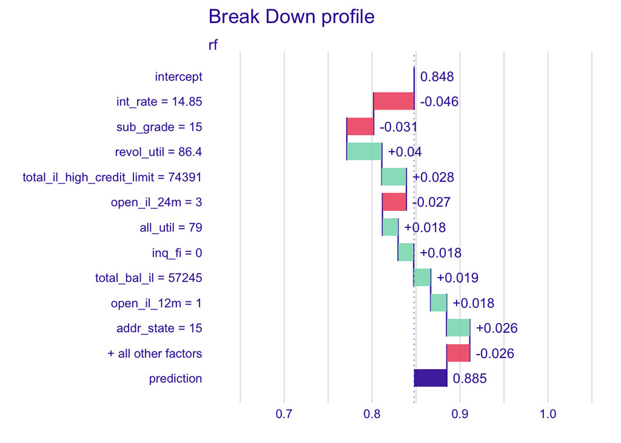

```r
pp_rf1 <- predict_parts(explainer = rf_dalex,
                       new_observation = obs1,
                       type = "break_down")
pp_rf2 <- predict_parts(explainer = rf_dalex,
                       new_observation = obs2,
                       type = "break_down")
pp_rf3 <- predict_parts(explainer = rf_dalex,
                       new_observation = obs3,
                       type = "break_down")
plot(pp_rf1)
```

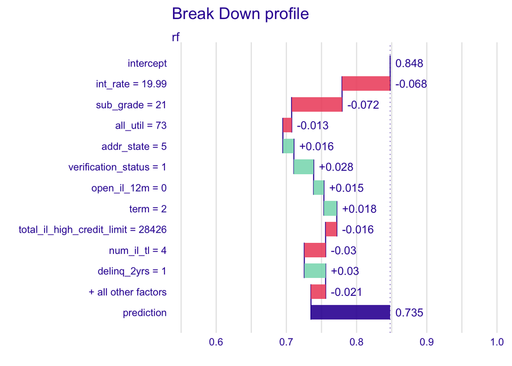

```r
plot(pp_rf2)
```

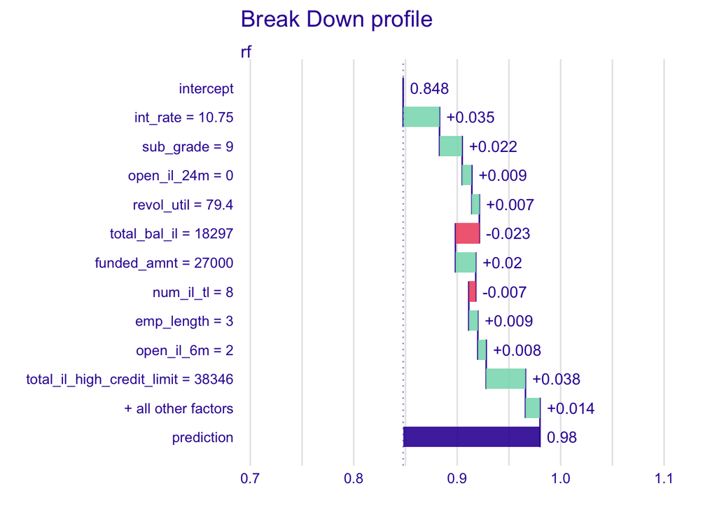

```r
plot(pp_rf3)
```

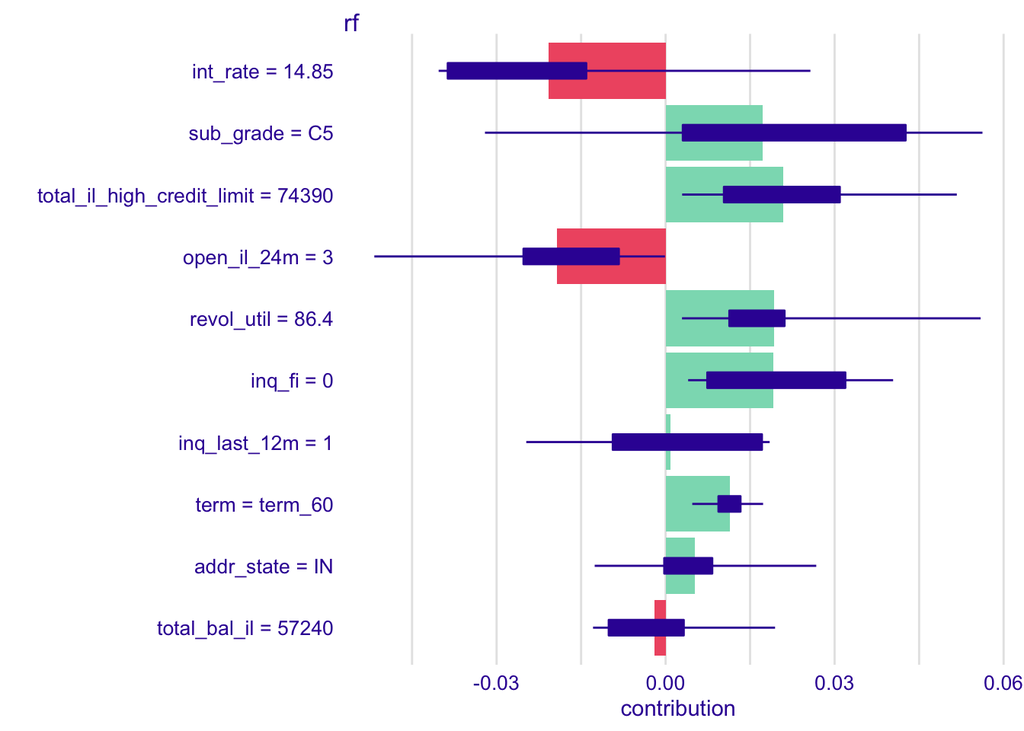

```r
rf_shap1 <-predict_parts(explainer = rf_dalex,
                        new_observation = obs1,
                        type = "shap",
                        B = 10
)
rf_shap2 <-predict_parts(explainer = rf_dalex,
                        new_observation = obs2,
                        type = "shap",
                        B = 10
)
rf_shap3 <-predict_parts(explainer = rf_dalex,
                        new_observation = obs3,
                        type = "shap",
                        B = 10
)
plot(rf_shap1)
```

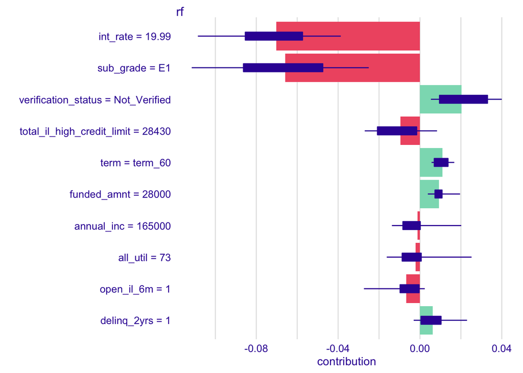

```r
plot(rf_shap2)
```

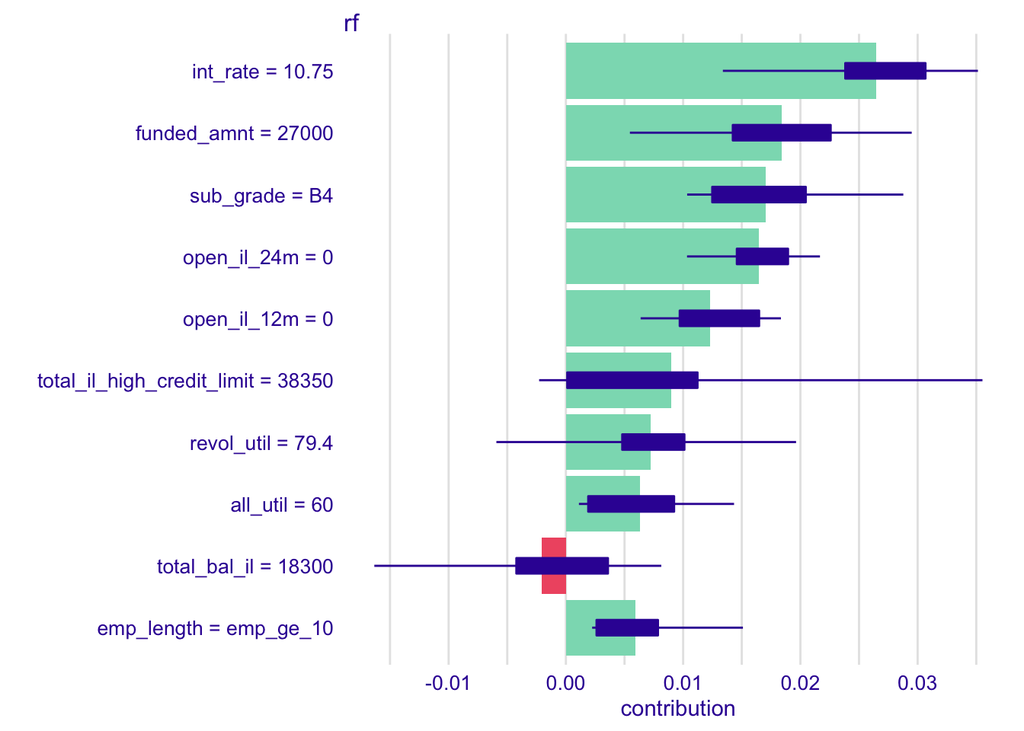

```r
plot(rf_shap3)
```

6. Describe how you would use the interpretable machine learning tools we’ve learned (both local and global) in future machine learning projects? How does each of them help you?

I would use the interpretable ML techniques to improve my understanding of what the models are communicating by becoming aware of the different interactions and impacts, especially when working with larger data sets. Taking what we worked on in the previous questions, these plots really provide insightful information regarding the models and different variables.

7. Save this final model using the `write_rds()` function - see the [Use the model](https://advanced-ds-in-r.netlify.app/posts/2021-03-16-ml-review/#use-the-model) section of the `tidymodels` intro for a similar example, but we’re using `write_rds()` instead of `saveRDS()`. We are going to use the model in the next part. You’ll want to save it in the folder where you create your shiny app. Run the code, and then add `eval=FALSE` to the code chunk options (next to the r inside the curly brackets) so it doesn’t rerun this each time you knit.

```r
write_rds(rf_final, "Final Model")
```

## Shiny app

You are going to create an app that allows a user to explore how the predicted probability of a loan being paid back (or maybe just the predicted class - either “good” or “bad”) changes depending on the values of the predictor variables.

Specifically, you will do the following:

- Set up a separate project and GitHub repo for this app. Make sure the saved model from the previous problem is also in that folder. The app needs to be created in a file called *exactly* app.R that is also in the project folder.
- At the top of the file, load any libraries you use in the app.
- Use the `read_rds()` function to load the model.
- You may want to load some of the lending data to use to help in the design of your app. The original data are in `tidymodels` which you will also have to load in the shiny app.
- Create a user interface (using the various `*Input()` functions) where someone could enter values for each variable that feeds into the model. You will want to think hard about which types of `*Input()` functions to use. Think about how you can best prevent mistakes (eg. entering free text could lead to many mistakes). I’d recommend using sliders and drop-downs as often as possible.
- Another part of the user interface will allow them to choose a variable (you can limit this to only the quantitative variables) where they can explore the effects of changing that variable, holding all others constant.
- After the user has entered all the required values, the output will be a CP profile with the the predicted value for the data that was entered, indicated by a point. You may be able to use the functions from `DALEX` and `DALEXtra` or you can do some of your own coding.
- Use the `bslib` to theme your shiny app!
- Publish your app to [shinyapps.io](https://www.shinyapps.io/). There are instructions for doing that on my tutorial page from Intro Data Science: https://animation-and-interactivity-in-r.netlify.app/#publishing-your-app. Make sure to load ALL the libraries that you use at the top of your file. This includes the ranger library, which is used “behind the scenes” when your model is fit. If you try to publish and are unsuccessful, forgetting a library you need is the most common reason I have seen.
- Write a paragraph or two describing your app on your website! Link to the app and your GitHub repository in your post. Include a link to your post here.

## Data Ethics: Data visualization principles

I’m hoping that the topic for this week is a review for all of you, but it’s good to remind ourselves of these principles.

**Task:**

Read both short articles in Week6. Data visualization section of [Calling Bulllshit](https://www.callingbullshit.org/syllabus.html#Visual). Were there any principles mentioned that you hadn’t heard of before? What graph stood out for you as “the worst”? Did any of the graphs fool you? Or were able to overcome the bad practices (don’t worry if they fool you - plently of them have fooled me, too.)? How does practicing good data visualization principles fit in with data ethics?

*Article Review*

The first thought that came to mind reading the article was how even professional bodies with seemingly reputable stature such as the German Economic Development Agency produced visualizations that are substandard, contributing to misleading conclusions. Although we get carried away with wanting to convey our interpretations, it is essential to always be aware of how even specific aspects that are usually overlooked, such as the ranges on the axis of graphs, can have large impacts on how the audience perceives them (for example - the difference between a line and bar graph). The worst graph in my opinion is the one produced in the World Inequality Report where the authors change the scale of the axis towards the end of the time period. The way I interpreted this was how they intended to mislead the audience, and although a more educated one would notice the subtle difference, there may be other audiences who would not capture this. In general, all of these graphs did not deceive me upon closer inspection but I can see how I would easily arrive to incorrect conclusions if I were following these in timed situations such as a presentation. I was interested to become aware of the Principle of Proportional Ink and although the fundamental ideas come naturally when ensuring that our visualizations do not led to misleading conclusions, I realized that I was not always aware of it completely.

## Make this document look nicer!

Go to the top and delete the `#` from the options section and knit a final time.